# ML Algorithms for classification

Decision trees

Hicham Zmarrou

Notebook – http://bit.ly/2q9NPSU

[Visit my website](http://trefoil.ml/) for more like this!

## Exercise 1

Consider the Kyphosis data frame(type `help("kyphosis")` for more details), that contains: -Kyphosis:a factor with levels absent present indicating if a kyphosis (a type of deformation) was present after the operation. -Age:in months. -Number:the number of vertebrae involved. -Start:the number of the first (topmost) vertebra operated on.

```r
library('rattle')
```

```r
library('rpart')
library("rpart.plot")
TREE=rpart(Kyphosis ~ Age + Number + Start, data=kyphosis,method="class")
TREE
```

```
## n= 81
##
## node), split, n, loss, yval, (yprob)
##       * denotes terminal node
##
##  1) root 81 17 absent (0.79012346 0.20987654)
##    2) Start>=8.5 62  6 absent (0.90322581 0.09677419)
##      4) Start>=14.5 29  0 absent (1.00000000 0.00000000) *
##      5) Start< 14.5 33  6 absent (0.81818182 0.18181818)
##       10) Age< 55 12  0 absent (1.00000000 0.00000000) *
##       11) Age>=55 21  6 absent (0.71428571 0.28571429)
##         22) Age>=111 14  2 absent (0.85714286 0.14285714) *
##         23) Age< 111 7  3 present (0.42857143 0.57142857) *
##    3) Start< 8.5 19  8 present (0.42105263 0.57894737) *
```

```r
#fancyRpartPlot(TREE)
```

1. Build a tree to classify Kyphosis from Age, Number and Start

## Exercise 2

Consider the tree build in exercise 1. 1) Which variables are used to explain kyhosis presence? 2) How many observations contains the terminal nodes.

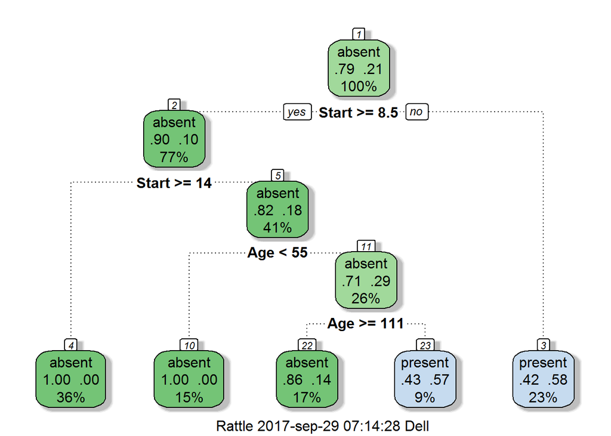

```r
fancyRpartPlot(TREE)
```

```r
TREE
```

```
## n= 81
##
## node), split, n, loss, yval, (yprob)
##       * denotes terminal node
##
##  1) root 81 17 absent (0.79012346 0.20987654)
##    2) Start>=8.5 62  6 absent (0.90322581 0.09677419)
##      4) Start>=14.5 29  0 absent (1.00000000 0.00000000) *
##      5) Start< 14.5 33  6 absent (0.81818182 0.18181818)
##       10) Age< 55 12  0 absent (1.00000000 0.00000000) *
##       11) Age>=55 21  6 absent (0.71428571 0.28571429)
##         22) Age>=111 14  2 absent (0.85714286 0.14285714) *
##         23) Age< 111 7  3 present (0.42857143 0.57142857) *
##    3) Start< 8.5 19  8 present (0.42105263 0.57894737) *
```

```r
printcp(TREE)
```

```
##
## Classification tree:
## rpart(formula = Kyphosis ~ Age + Number + Start, data = kyphosis,
##     method = "class")
##
## Variables actually used in tree construction:
## [1] Age   Start
##
## Root node error: 17/81 = 0.20988
##
## n= 81
##
##         CP nsplit rel error xerror    xstd
## 1 0.176471      0   1.00000 1.0000 0.21559
## 2 0.019608      1   0.82353 1.1765 0.22829
## 3 0.010000      4   0.76471 1.1765 0.22829
```

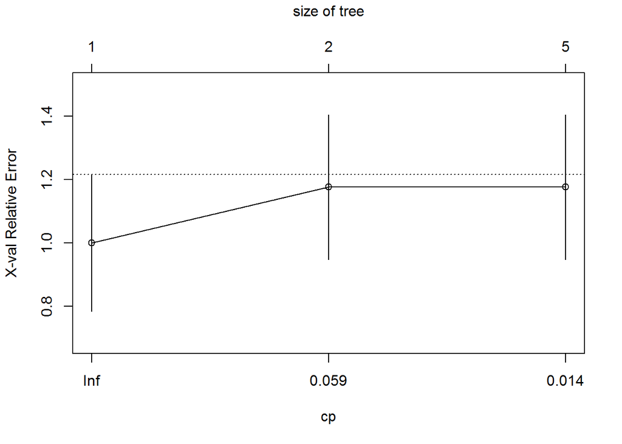

```r
plotcp(TREE)
```

## Exercise 3

Consider the Kyphosis data frame. 1)Build a tree using the first 60 observations of kyphosis.

```r
TREE=rpart(Kyphosis ~ Age + Number + Start, data=kyphosis[1:60,],method="class")
```

2)Predict the kyphosis presence for the other 21 observations.

```r
PR=predict(TREE,kyphosis[61:81,],type='class')
```

3)Which is the misclassification rate (prediction error)

```r
test=kyphosis$Kyphosis[61:81]
table(PR,test)
```

```
##          test
## PR        absent present
##   absent      14       2
##   present      3       2
```

```r
rate=100*length(which(PR!=test))/length(PR)
```

The misclassification rate is: 23.8095238

## Exercise 4

Consider the iris data frame(type `help('iris')` for more details). 1)Build a tree to classify Species from the other variables.

```r
TREE2=rpart(Species ~ ., data=iris,method="class")
TREE2
```

```
## n= 150
##
## node), split, n, loss, yval, (yprob)
##       * denotes terminal node
##
## 1) root 150 100 setosa (0.33333333 0.33333333 0.33333333)
##   2) Petal.Length< 2.45 50   0 setosa (1.00000000 0.00000000 0.00000000) *
##   3) Petal.Length>=2.45 100  50 versicolor (0.00000000 0.50000000 0.50000000)
##     6) Petal.Width< 1.75 54   5 versicolor (0.00000000 0.90740741 0.09259259) *
##     7) Petal.Width>=1.75 46   1 virginica (0.00000000 0.02173913 0.97826087) *
```

2)Plot the trees.

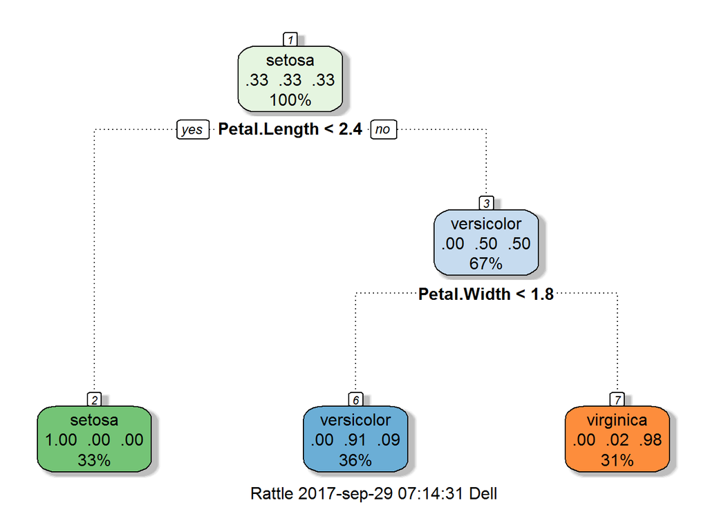

```r
fancyRpartPlot(TREE2)
```

## Exercise 5

Consider the tree build in exercise 4. 1) Prune the the using median complexity parameter (cp) associated to the tree.

```r
TP=prune(TREE2,cp=median(TREE2$cptable[,'CP']))
```

2. Plot in the same window the pruned and the original tree.

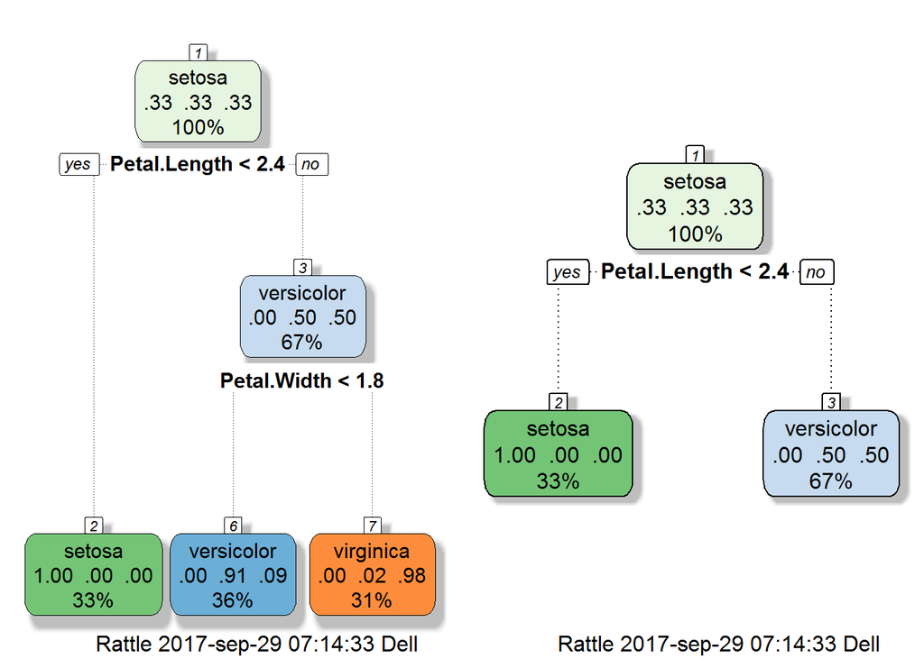

```r
par(mfrow=c(1,2))

fancyRpartPlot(TREE2)
fancyRpartPlot(TP)
```

## Exercise 6

Consider the tree build in exercise 4. 1)In which terminal nodes is clasified each observations of iris?

```r
TREE2$where
```

```
##   1   2   3   4   5   6   7   8   9  10  11  12  13  14  15  16  17  18
##   2   2   2   2   2   2   2   2   2   2   2   2   2   2   2   2   2   2
##  19  20  21  22  23  24  25  26  27  28  29  30  31  32  33  34  35  36
##   2   2   2   2   2   2   2   2   2   2   2   2   2   2   2   2   2   2
##  37  38  39  40  41  42  43  44  45  46  47  48  49  50  51  52  53  54
##   2   2   2   2   2   2   2   2   2   2   2   2   2   2   4   4   4   4
##  55  56  57  58  59  60  61  62  63  64  65  66  67  68  69  70  71  72
##   4   4   4   4   4   4   4   4   4   4   4   4   4   4   4   4   5   4
##  73  74  75  76  77  78  79  80  81  82  83  84  85  86  87  88  89  90
##   4   4   4   4   4   4   4   4   4   4   4   4   4   4   4   4   4   4
##  91  92  93  94  95  96  97  98  99 100 101 102 103 104 105 106 107 108
##   4   4   4   4   4   4   4   4   4   4   5   5   5   5   5   5   4   5
## 109 110 111 112 113 114 115 116 117 118 119 120 121 122 123 124 125 126
##   5   5   5   5   5   5   5   5   5   5   5   4   5   5   5   5   5   5
## 127 128 129 130 131 132 133 134 135 136 137 138 139 140 141 142 143 144
##   5   5   5   4   5   5   5   4   4   5   5   5   5   5   5   5   5   5
## 145 146 147 148 149 150
##   5   5   5   5   5   5
```

2)Which Specie has a flower of Petal.Length greater than 2.45 and Petal.Width less than 1.75.

## Exercise 7

Consider the car90 data frame(type help(‘car90’) for more details). 1)Build a tree to predict Price from the other variables.

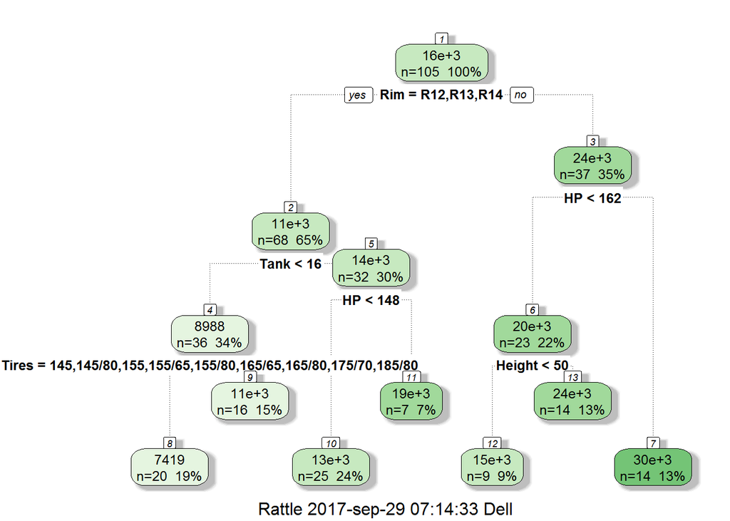

```r
tree=rpart(Price ~ ., data=car90,method="anova")
fancyRpartPlot(tree)
```

2)Plot the trees, add nodes information.

## Exercise 8

Consider the tree build in exercise 7. 1) Which variables are used to explain the price?

```r
tree
```

```
## n=105 (6 observations deleted due to missingness)
##
## node), split, n, deviance, yval
##       * denotes terminal node
##
##  1) root 105 7118267000 15805.220
##    2) Rim=R12,R13,R14 68 1101501000 11487.500
##      4) Tank< 15.65 36  189145300  8988.278
##        8) Tires=145,145/80,155,155/65,155/80,165/65,165/80,175/70,185/80 20   31853590  7419.050 *
##        9) Tires=185/60,185/70,195/60,195/70,195/75,205/75 16   46480320 10949.810 *
##      5) Tank>=15.65 32  434528300 14299.120
##       10) HP< 147.5 25  119553300 13014.720 *
##       11) HP>=147.5 7  126438300 18886.290 *
##    3) Rim=R15,R16,R17 37 2419229000 23740.490
##      6) HP< 162.5 23  863713000 20147.610
##       12) Height< 49.75 9   87042290 14755.000 *
##       13) Height>=49.75 14  346698700 23614.290 *
##      7) HP>=162.5 14  770847400 29643.070 *
```

```r
printcp(tree)
```

```
##
## Regression tree:
## rpart(formula = Price ~ ., data = car90, method = "anova")
##
## Variables actually used in tree construction:
## [1] Height HP     Rim    Tank   Tires
##
## Root node error: 7118267246/105 = 67793021
##
## n=105 (6 observations deleted due to missingness)
##
##         CP nsplit rel error  xerror     xstd
## 1 0.505395      0   1.00000 1.01578 0.161886
## 2 0.110233      1   0.49460 0.52716 0.090764
## 3 0.067127      2   0.38437 0.53595 0.110683
## 4 0.060404      3   0.31724 0.54190 0.115056
## 5 0.026486      4   0.25684 0.53749 0.139055
## 6 0.015567      5   0.23035 0.54305 0.139878
## 7 0.010000      6   0.21479 0.54084 0.140374
```

2)Which terminal nodes have a value of mean Price, less than mean(car90$Price)?

```r
summary(tree)
```

```
## Call:
## rpart(formula = Price ~ ., data = car90, method = "anova")
##   n=105 (6 observations deleted due to missingness)
##
##           CP nsplit rel error    xerror       xstd
## 1 0.50539502      0 1.0000000 1.0157835 0.16188599
## 2 0.11023313      1 0.4946050 0.5271637 0.09076403
## 3 0.06712695      2 0.3843719 0.5359460 0.11068326
## 4 0.06040402      3 0.3172449 0.5419003 0.11505591
## 5 0.02648632      4 0.2568409 0.5374943 0.13905459
## 6 0.01556719      5 0.2303546 0.5430450 0.13987762
## 7 0.01000000      6 0.2147874 0.5408355 0.14037370
##
## Variable importance
##          Rim        Tires         Tank           HP         Disp
##           18           15           14           14           11
##        Disp2       Weight         Type       Height     Steering
##           10            3            3            2            2
##     Sratio.p   Wheel.base       Length      Rear.Hd Rear.Seating
##            2            2            1            1            1
##        Gear2       Model2
##            1            1
##
## Node number 1: 105 observations,    complexity param=0.505395
##   mean=15805.22, MSE=6.779302e+07
##   left son=2 (68 obs) right son=3 (37 obs)
##   Primary splits:
##       Rim   splits as  LLLRRR, improve=0.5053950, (0 missing)
##       Tires splits as  LLLLLLLLLLRLLLRLRLLRRRLLRRRRRR, improve=0.4721902, (0 missing)
##       Disp  < 156    to the left,  improve=0.4601461, (0 missing)
##       Disp2 < 2.55   to the left,  improve=0.4601461, (0 missing)
##       HP    < 154    to the left,  improve=0.4548845, (0 missing)
##   Surrogate splits:
##       Tires splits as  LLLLLLLLLLRLLLRLRLLRRRLRRRRRRR, agree=0.876, adj=0.649, (0 split)
##       Tank  < 17.8   to the left,  agree=0.848, adj=0.568, (0 split)
##       Disp  < 156    to the left,  agree=0.829, adj=0.514, (0 split)
##       Disp2 < 2.55   to the left,  agree=0.829, adj=0.514, (0 split)
##       HP    < 126.5  to the left,  agree=0.819, adj=0.486, (0 split)
##
## Node number 2: 68 observations,    complexity param=0.06712695
```

[output cut: 84 more lines]

```
##
## Node number 9: 16 observations
##   mean=10949.81, MSE=2905020
##
## Node number 10: 25 observations
##   mean=13014.72, MSE=4782130
##
## Node number 11: 7 observations
##   mean=18886.29, MSE=1.806262e+07
##
## Node number 12: 9 observations
##   mean=14755, MSE=9671366
##
## Node number 13: 14 observations
##   mean=23614.29, MSE=2.47642e+07
```

## Exercise 9

Consider the car.test.frame data frame (type help(‘car.test.frame’) for more details). 1)Build a tree to explain Mileage using the other variables.

```r
TC=rpart(Mileage~., data=car.test.frame)
TC
```

```
## n= 60
##
## node), split, n, deviance, yval
##       * denotes terminal node
##
##  1) root 60 1354.58300 24.58333
##    2) Disp.>=134 35  154.40000 21.40000
##      4) Type=Large,Van 10   22.10000 19.30000 *
##      5) Type=Compact,Medium,Sporty 25   70.56000 22.24000
##       10) Price>=11522 18   26.44444 21.55556 *
##       11) Price< 11522 7   14.00000 24.00000 *
##    3) Disp.< 134 25  348.96000 29.04000
##      6) Price>=9504.5 13   32.30769 26.23077 *
##      7) Price< 9504.5 12  102.91670 32.08333 *
```

2)Snip the tree in nodes number 2.

```r
TS=snip.rpart(TC,toss=2)
```

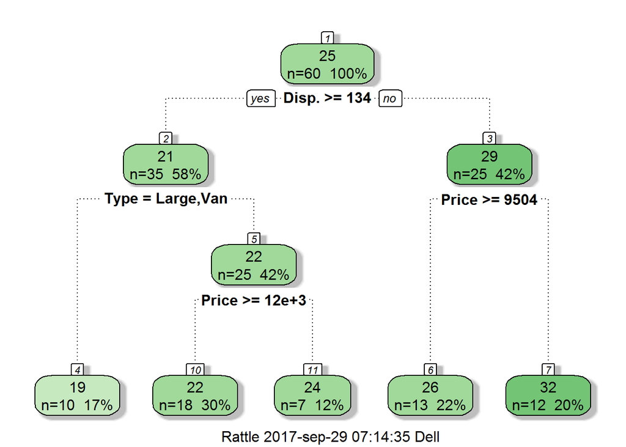

```r
fancyRpartPlot(TC)
```

## Exercise 10

Consider the tree build in exercise 9. 2). Which is the depth of the tree (with the root node counted as depth 0). 3). Set the maximum depth of the final tree on 2

[figure not shown]

```r
TC2=rpart(Mileage~., data=car.test.frame,maxdepth=2)
fancyRpartPlot(TC2)
```

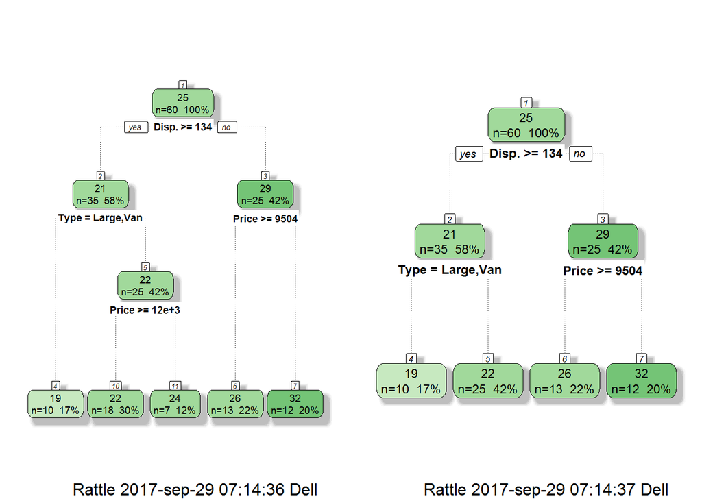

```r
#plot both together
par(mfrow=c(1,2))
fancyRpartPlot(TC)

fancyRpartPlot(TC2)
```